# Intuit X Alicia Ge

### Now let see what are the factors that effect people’s decision on paying for tax!

Read both train data and test data in.

```r
setwd("/Users/G_bgyl/Documents/Umich/Intern_Job/2018\ Summer\ Internship/Intuit\ Data\ Challenge/intuit_code")
train_zia = read.csv("train_zia.csv")
test_zia = read.csv("test_zia.csv")
cols <- c(7:18,24:86)

train_zia_clean = train_zia[,cols]
```

### Let’s create our first model!

I used num_paid_preparer_returns as the value we want to predict.

This number is important because it represent on what level people are willing to pay for tax return.

In this first block,, I modeled a full model, take every numeric cloumns into account.

I comment out most of the code, because this is really a draft model and should not work at all. This is a baseline of modeling, by this way I can get a rough idea of each column.

I keep the code just want to show what I did.

```r
#train_irs_clean$agi_stub <- factor(train_irs_clean$agi_stub)

m1 = lm(num_paid_preparer_returns~.,data = train_zia_clean)

## plot the model:
#par(mfrow=c(2,2))
#plot(m1)
#summary(m1)

## check outlier
#ti <- rstudent(m1)
#max(abs(ti))
#ti[which.max(abs(ti))]

## cook distance
#library(faraway)
#cook <- cooks.distance(m6)
#halfnorm(cook, nlab = 3, ylab="Cooks distance")

## compare the loss of the model between train data and test data:
#train_MSE = mean(m1$residuals^2)
#test_MSE = mean((test_zia$num_paid_preparer_returns - predict.lm(m1, test_zia)) ^ 2)
#train_MSE
#test_MSE
```

### Adjust model

For the predictors, I cut out most of the predictors that do not have a significant affect on the model(P value is large). Since column agi_stub is a category of adjusted gross income , I turned it into a factor.

I both plot and summary the model, to better evalute the model. The left two residual plot shows that there is a problem of Heteroscedasticity, means the variance become bigger as the X goes up. The QQ plot shows the problem of normality. The last graph shows that there are several leverage points. I further checked lerverage point and influencial point to help improving latter.

```r
train_zia_clean$agi_stub <- factor(train_zia_clean$agi_stub)

m2 = lm(num_paid_preparer_returns~
          train_zia_clean$agi_stub + train_zia_clean$num_returns + train_zia_clean$num_single_returns + train_zia_clean$num_joint_returns + train_zia_clean$num_head_of_household_returns + train_zia_clean$num_exemptions + train_zia_clean$num_dependents + log(train_zia_clean$amount_agi) +train_zia_clean$amount_refunds +
          train_zia_clean$Total..Estimate..AGE...60.to.64.years + train_zia_clean$Male..Estimate..Total.population + train_zia_clean$Total..Estimate..Total.population+ train_zia_clean$Total..Estimate..SUMMARY.INDICATORS...Old.age.dependency.ratio ,data = train_zia_clean)

par(mfrow=c(2,2))
plot(m2)
summary(m2)
```

```
##
## Call:
## lm(formula = num_paid_preparer_returns ~ train_zia_clean$agi_stub +
##     train_zia_clean$num_returns + train_zia_clean$num_single_returns +
##     train_zia_clean$num_joint_returns + train_zia_clean$num_head_of_household_returns +
##     train_zia_clean$num_exemptions + train_zia_clean$num_dependents +
##     log(train_zia_clean$amount_agi) + train_zia_clean$amount_refunds +
##     train_zia_clean$Total..Estimate..AGE...60.to.64.years + train_zia_clean$Male..Estimate..Total.population +
##     train_zia_clean$Total..Estimate..Total.population + train_zia_clean$Total..Estimate..SUMMARY.INDICATORS...Old.age.dependency.ratio,
##     data = train_zia_clean)
##
## Residuals:
##     Min      1Q  Median      3Q     Max
## -2890.4   -68.4    -0.8    75.4  7589.8
##
## Coefficients:
##                                                                                  Estimate
## (Intercept)                                                                     4.187e+02
## train_zia_clean$agi_stub2                                                       4.978e+01
## train_zia_clean$agi_stub3                                                       1.344e+02
## train_zia_clean$agi_stub4                                                       1.489e+02
## train_zia_clean$agi_stub5                                                       1.787e+02
## train_zia_clean$agi_stub6                                                       3.885e+02
## train_zia_clean$num_returns                                                    -7.129e-01
## train_zia_clean$num_single_returns                                              1.046e+00
## train_zia_clean$num_joint_returns                                               8.058e-01
## train_zia_clean$num_head_of_household_returns                                   1.036e+00
## train_zia_clean$num_exemptions                                                  1.824e-01
## train_zia_clean$num_dependents                                                 -5.229e-02
## log(train_zia_clean$amount_agi)                                                -6.306e+01
## train_zia_clean$amount_refunds                                                  7.632e-03
## train_zia_clean$Total..Estimate..AGE...60.to.64.years                           3.707e+00
## train_zia_clean$Male..Estimate..Total.population                                6.163e-03
## train_zia_clean$Total..Estimate..Total.population                              -2.171e-03
## train_zia_clean$Total..Estimate..SUMMARY.INDICATORS...Old.age.dependency.ratio  3.248e+00
##                                                                                Std. Error
## (Intercept)                                                                     1.894e+01
## train_zia_clean$agi_stub2                                                       3.599e+00
## train_zia_clean$agi_stub3                                                       4.376e+00
## train_zia_clean$agi_stub4                                                       5.262e+00
```

[output cut: 62 more lines]

```
## train_zia_clean$num_head_of_household_returns                                  ***
## train_zia_clean$num_exemptions                                                 ***
## train_zia_clean$num_dependents                                                 ***
## log(train_zia_clean$amount_agi)                                                ***
## train_zia_clean$amount_refunds                                                 ***
## train_zia_clean$Total..Estimate..AGE...60.to.64.years                          ***
## train_zia_clean$Male..Estimate..Total.population                               **
## train_zia_clean$Total..Estimate..Total.population                              *
## train_zia_clean$Total..Estimate..SUMMARY.INDICATORS...Old.age.dependency.ratio ***
## ---
## Signif. codes:  0 '***' 0.001 '**' 0.01 '*' 0.05 '.' 0.1 ' ' 1
##
## Residual standard error: 268.9 on 77214 degrees of freedom
## Multiple R-squared:  0.9381, Adjusted R-squared:  0.9381
## F-statistic: 6.881e+04 on 17 and 77214 DF,  p-value: < 2.2e-16
```

```r
# find outlier
ti <- rstudent(m2)
max(abs(ti))
```

```
## [1] 28.79539
```

```r
ti[which.max(abs(ti))]
```

```
##    31496
## 28.79539
```

```r
library(faraway)
```

[figure not shown]

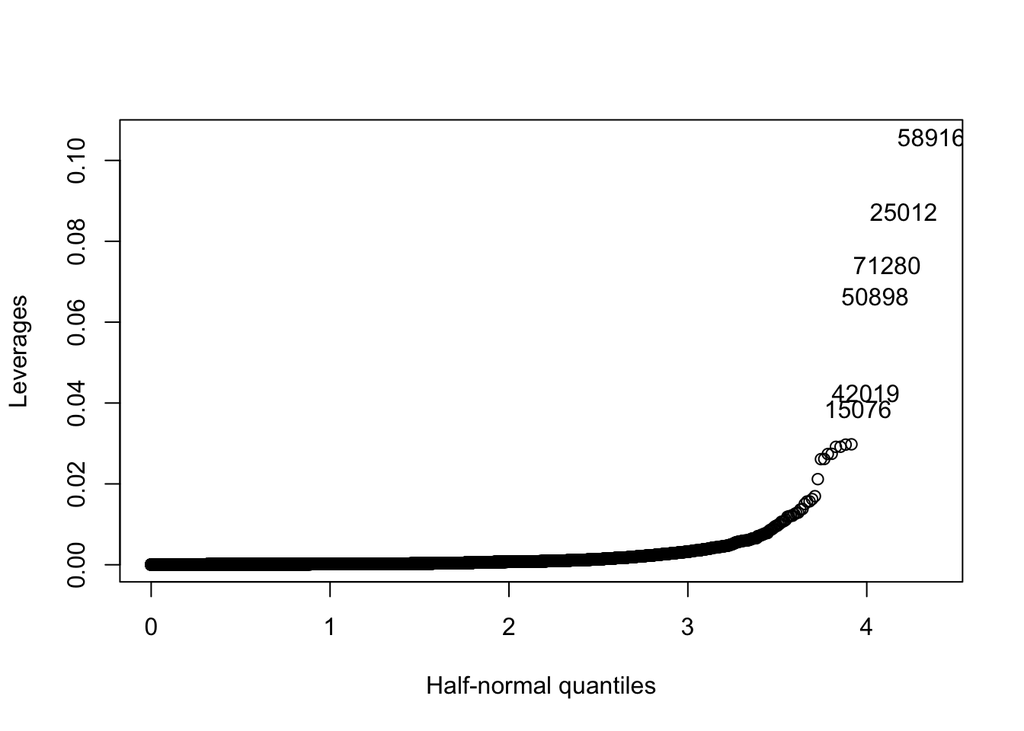

```r
#find leverage
par(mfrow=c(1,1))
halfnorm(hatvalues(m2), nlab = 6, ylab="Leverages")
```

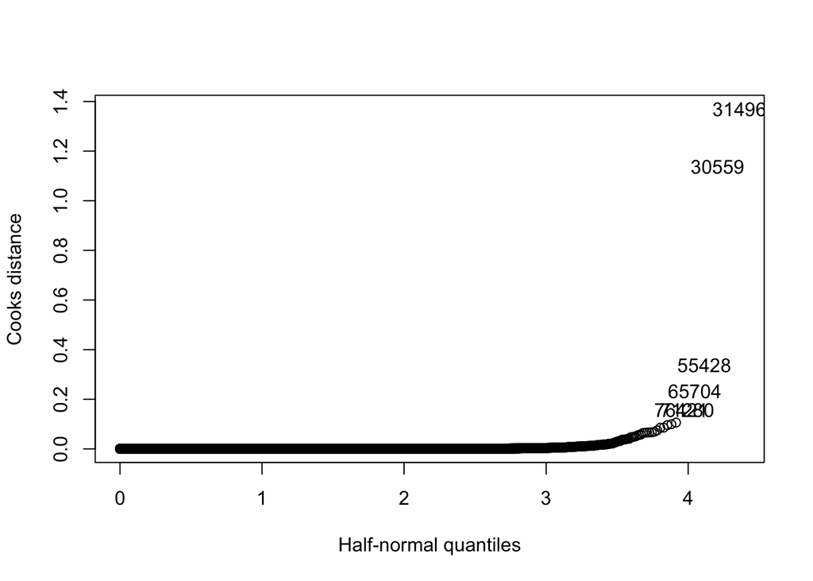

```r
#cook distance
cook <- cooks.distance(m2)
par(mfrow=c(1,1))
halfnorm(cook, nlab = 6, ylab="Cooks distance")
```

```r
# compare the loss of the model between train data and test data
train_MSE_2 = mean(m2$residuals^2)
test_MSE_2 = mean((test_zia$num_paid_preparer_returns - predict.lm(m2, test_zia)) ^ 2)
train_MSE_2
```

```
## [1] 72311.54
```

```r
test_MSE_2
```

```
## [1] 2321687
```

### Trade off: balance between a good fit and a good prediction

To further improve the second model, I tried two ways: 1. To solve the problem of model fitting, I log the dependent variable(y). 2. I also drop several predictors and transform some others. These features are shown in model 4.

However, as model 4 becomes a good fit of training model, its power of prediction remains bad.

In this way, I compromise between a good fit and a good prediction, choose model 3 as the final solution. It didn’t use log(y) to help solve the Heteroscedasticity and normality problem, but it has a good prediction.

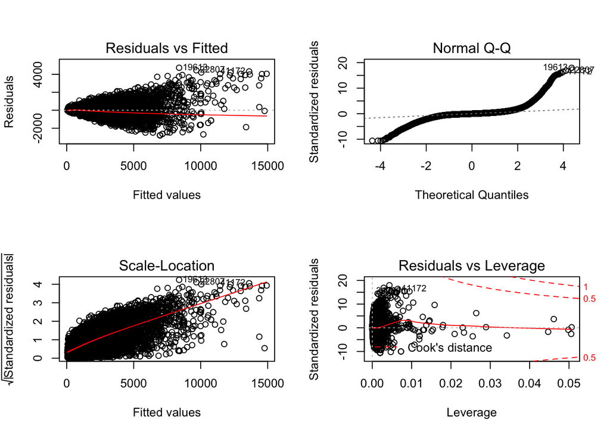

```r
# drop leverage point and influence point
tzc_drop_ol <- train_zia_clean[-c(15076, 42019, 50898,25012,58916,
                                  55428, 30559, 31496,71280,65704,76421), ]

#keep agi_stub as a factor
tzc_drop_ol$agi_stub <- factor(tzc_drop_ol$agi_stub)
test_zia$agi_stub <- factor(test_zia$agi_stub)

m3 = lm( num_paid_preparer_returns ~
          agi_stub + num_returns + num_single_returns + num_joint_returns + num_head_of_household_returns + num_exemptions + log(num_dependents) + log(amount_agi) +amount_refunds + Total..Estimate..AGE...60.to.64.years + Male..Estimate..Total.population + Total..Estimate..SUMMARY.INDICATORS...Old.age.dependency.ratio ,data = tzc_drop_ol)


par(mfrow=c(2,2))
plot(m3)
```

```r
summary(m3)
```

```
##
## Call:
## lm(formula = num_paid_preparer_returns ~ agi_stub + num_returns +
##     num_single_returns + num_joint_returns + num_head_of_household_returns +
##     num_exemptions + log(num_dependents) + log(amount_agi) +
##     amount_refunds + Total..Estimate..AGE...60.to.64.years +
##     Male..Estimate..Total.population + Total..Estimate..SUMMARY.INDICATORS...Old.age.dependency.ratio,
##     data = tzc_drop_ol)
##
## Residuals:
##     Min      1Q  Median      3Q     Max
## -2786.6   -66.4    -1.2    71.5  4729.9
##
## Coefficients:
##                                                                  Estimate
## (Intercept)                                                     1.832e+02
## agi_stub2                                                       1.184e+01
## agi_stub3                                                       7.102e+01
## agi_stub4                                                       6.770e+01
## agi_stub5                                                       8.781e+01
## agi_stub6                                                       2.201e+02
## num_returns                                                    -6.603e-01
## num_single_returns                                              9.974e-01
## num_joint_returns                                               7.778e-01
## num_head_of_household_returns                                   1.002e+00
## num_exemptions                                                  1.466e-01
## log(num_dependents)                                            -3.523e+01
## log(amount_agi)                                                -1.302e+01
## amount_refunds                                                  9.271e-03
## Total..Estimate..AGE...60.to.64.years                           3.247e+00
## Male..Estimate..Total.population                                2.729e-03
## Total..Estimate..SUMMARY.INDICATORS...Old.age.dependency.ratio  3.185e+00
##                                                                Std. Error
## (Intercept)                                                     2.027e+01
## agi_stub2                                                       4.131e+00
## agi_stub3                                                       5.612e+00
## agi_stub4                                                       6.804e+00
## agi_stub5                                                       8.699e+00
## agi_stub6                                                       1.350e+01
## num_returns                                                     2.682e-02
```

[output cut: 55 more lines]

```
## num_joint_returns                                              ***
## num_head_of_household_returns                                  ***
## num_exemptions                                                 ***
## log(num_dependents)                                            ***
## log(amount_agi)                                                ***
## amount_refunds                                                 ***
## Total..Estimate..AGE...60.to.64.years                          ***
## Male..Estimate..Total.population                               ***
## Total..Estimate..SUMMARY.INDICATORS...Old.age.dependency.ratio ***
## ---
## Signif. codes:  0 '***' 0.001 '**' 0.01 '*' 0.05 '.' 0.1 ' ' 1
##
## Residual standard error: 263.8 on 77204 degrees of freedom
## Multiple R-squared:  0.9387, Adjusted R-squared:  0.9387
## F-statistic: 7.384e+04 on 16 and 77204 DF,  p-value: < 2.2e-16
```

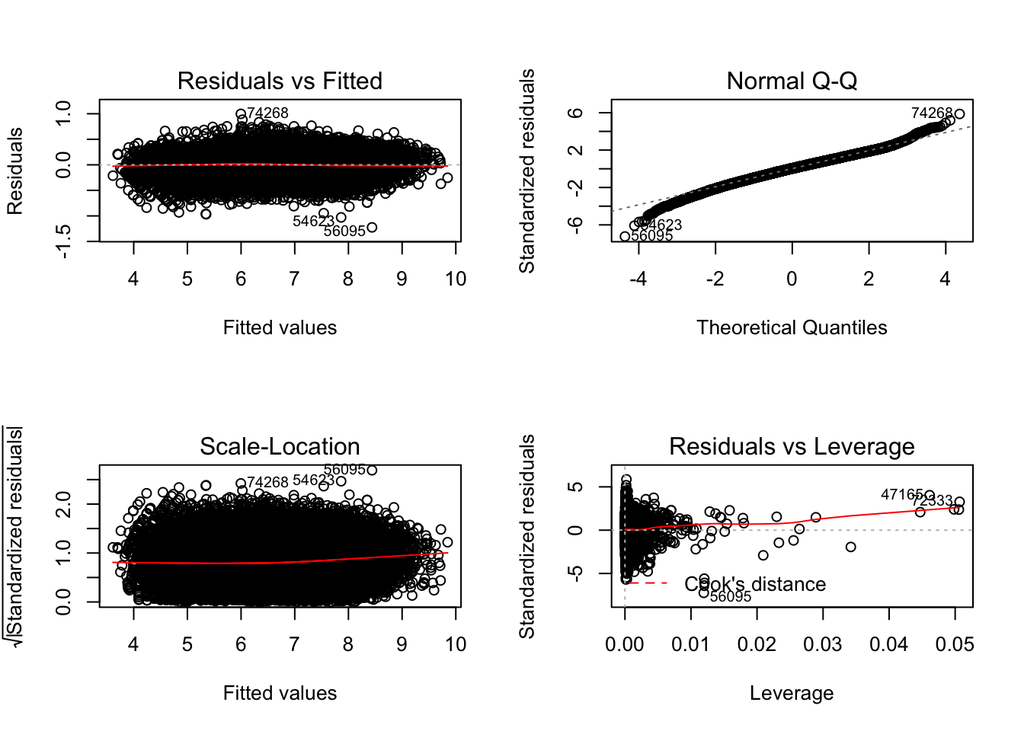

```r
m4 = lm( log(num_paid_preparer_returns) ~
          agi_stub + num_returns + num_single_returns + num_joint_returns + num_head_of_household_returns + num_exemptions + log(num_dependents) + log(amount_agi) +amount_refunds + Total..Estimate..AGE...60.to.64.years + Male..Estimate..Total.population + Total..Estimate..SUMMARY.INDICATORS...Old.age.dependency.ratio ,data = tzc_drop_ol)

par(mfrow=c(2,2))
plot(m4)
```

```r
summary(m4)
```

```
##
## Call:
## lm(formula = log(num_paid_preparer_returns) ~ agi_stub + num_returns +
##     num_single_returns + num_joint_returns + num_head_of_household_returns +
##     num_exemptions + log(num_dependents) + log(amount_agi) +
##     amount_refunds + Total..Estimate..AGE...60.to.64.years +
##     Male..Estimate..Total.population + Total..Estimate..SUMMARY.INDICATORS...Old.age.dependency.ratio,
##     data = tzc_drop_ol)
##
## Residuals:
##      Min       1Q   Median       3Q      Max
## -1.22444 -0.10782  0.00699  0.11407  0.99801
##
## Coefficients:
##                                                                  Estimate
## (Intercept)                                                    -2.135e+00
## agi_stub2                                                      -8.893e-01
## agi_stub3                                                      -1.303e+00
## agi_stub4                                                      -1.612e+00
## agi_stub5                                                      -1.909e+00
## agi_stub6                                                      -2.730e+00
## num_returns                                                    -2.977e-04
## num_single_returns                                              2.992e-04
## num_joint_returns                                               2.750e-04
## num_head_of_household_returns                                   3.447e-04
## num_exemptions                                                  6.830e-06
## log(num_dependents)                                             9.164e-02
## log(amount_agi)                                                 8.220e-01
## amount_refunds                                                 -6.342e-06
## Total..Estimate..AGE...60.to.64.years                          -2.734e-03
## Male..Estimate..Total.population                                5.904e-06
## Total..Estimate..SUMMARY.INDICATORS...Old.age.dependency.ratio  3.694e-03
##                                                                Std. Error
## (Intercept)                                                     1.307e-02
## agi_stub2                                                       2.665e-03
## agi_stub3                                                       3.620e-03
## agi_stub4                                                       4.389e-03
## agi_stub5                                                       5.612e-03
## agi_stub6                                                       8.706e-03
## num_returns                                                     1.730e-05
```

[output cut: 55 more lines]

```
## num_joint_returns                                              ***
## num_head_of_household_returns                                  ***
## num_exemptions                                                 ***
## log(num_dependents)                                            ***
## log(amount_agi)                                                ***
## amount_refunds                                                 ***
## Total..Estimate..AGE...60.to.64.years                          ***
## Male..Estimate..Total.population                               ***
## Total..Estimate..SUMMARY.INDICATORS...Old.age.dependency.ratio ***
## ---
## Signif. codes:  0 '***' 0.001 '**' 0.01 '*' 0.05 '.' 0.1 ' ' 1
##
## Residual standard error: 0.1701 on 77204 degrees of freedom
## Multiple R-squared:  0.9694, Adjusted R-squared:  0.9694
## F-statistic: 1.53e+05 on 16 and 77204 DF,  p-value: < 2.2e-16
```

```r
# compare the loss of the model between train data and test data
train_MSE_3 = mean(m3$residuals^2)
test_MSE_3 = mean((test_zia$num_paid_preparer_returns - predict.lm(m3, test_zia)) ^ 2)

train_MSE_3
```

```
## [1] 69552.08
```

```r
test_MSE_3
```

```
## [1] 73308.09
```

```r
# compare the loss of the model between train data and test data
train_MSE_4 = mean(m4$residuals^2)
test_MSE_4 = mean((test_zia$num_paid_preparer_returns - predict.lm(m4, test_zia)) ^ 2)

train_MSE_4
```

```
## [1] 0.02894283
```

```r
test_MSE_4
```

```
## [1] 2044445
```